# Module 2 - Quiz

Sasha Ajay Malkani

2025-11-18

## Question 1

### 1. A. Load Libraries

```r
library(devtools)
library(Biobase)
```

### 1. B. Load the Montgomery and Pickrell eSet:

```r
con =url("http://bowtie-bio.sourceforge.net/recount/ExpressionSets/montpick_eset.RData")
load(file=con)
close(con)
mp = montpick.eset
ls()
```

```
## [1] "con"           "montpick.eset" "mp"
```

```r
pdata=pData(mp)
head(pdata)
```

```
##         sample.id num.tech.reps population      study
## NA06985   NA06985             1        CEU Montgomery
## NA06986   NA06986             1        CEU Montgomery
## NA06994   NA06994             1        CEU Montgomery
## NA07000   NA07000             1        CEU Montgomery
## NA07037   NA07037             1        CEU Montgomery
## NA07051   NA07051             1        CEU Montgomery
```

```r
edata=as.data.frame(exprs(mp))
head(edata)
```

```
##                 NA06985 NA06986 NA06994 NA07000 NA07037 NA07051 NA07346 NA07347
## ENSG00000000003       0       0       0       1       0       0       0       0
## ENSG00000000005       0       0       0       0       0       0       0       0
## ENSG00000000419      11      16      10      19       8      24      14      19
## ENSG00000000457      28      22      17      21      18      15      21      13
## ENSG00000000460       0       7       2       4       6       3       8       5
## ENSG00000000938       8      28      20      10      17       4      19      35
##                 NA07357 NA10847 NA10851 NA11829 NA11830 NA11831 NA11832 NA11840
## ENSG00000000003       0       0       0       0       0       0       0       0
## ENSG00000000005       0       0       0       0       0       0       0       0
## ENSG00000000419      20       6      16       9       8      19      38      40
## ENSG00000000457      18      15      22      20      18      38      46      49
## ENSG00000000460       2       2       4       2       4       7      17      10
## ENSG00000000938      16       9      22       9      21      42      24      36
##                 NA11881 NA11894 NA11918 NA11920 NA11931 NA11992 NA11993 NA11994
## ENSG00000000003       0       0       0       0       1       0       0       0
## ENSG00000000005       0       0       0       0       0       0       0       0
## ENSG00000000419      16      24      16      60      80      43      14      38
## ENSG00000000457      14      14      10      21      46      55      10      37
## ENSG00000000460       1       7       6      18      20       7       0      10
## ENSG00000000938      19      22       0       8      15      27       6      23
##                 NA11995 NA12003 NA12004 NA12005 NA12006 NA12043 NA12044 NA12045
## ENSG00000000003       0       0       0       0       0       0       0       1
## ENSG00000000005       0       0       0       0       0       0       0       0
## ENSG00000000419      21      25       0      16      51      42      65      61
## ENSG00000000457      42      16      19      30      19      72      95      69
## ENSG00000000460       6       9       0       0       0      15      15      14
## ENSG00000000938       5      22       0      49      60      25      15      57
##                 NA12144 NA12154 NA12155 NA12156 NA12234 NA12249 NA12287 NA12414
## ENSG00000000003       0       0       0       0       0       0       0       1
## ENSG00000000005       0       0       0       0       0       0       0       1
## ENSG00000000419      35      37      42      20      33      36      29      47
## ENSG00000000457      20      59      41      27      38      42      28      55
## ENSG00000000460       9       9       5       5      12       5      11       5
## ENSG00000000938      27      25       6      11      27      13       5      34
##                 NA12489 NA12716 NA12717 NA12750 NA12751 NA12760 NA12761 NA12762
## ENSG00000000003       0       0       0       0       0       0       0       0
## ENSG00000000005       0       0       0       0       0       0       0       0
## ENSG00000000419      30      16      16      25      25      24      21      19
## ENSG00000000457      41      44      14      24      33      51      10       9
```

[output cut: 64 more lines]

```
## ENSG00000000938      73      12     100      71      55      28      35      50
##                 NA19203 NA19204 NA19209 NA19210 NA19222 NA19225 NA19238 NA19239
## ENSG00000000003       0       0       0       0       0       0       0       0
## ENSG00000000005       0       0       0       0       0       0       0       0
## ENSG00000000419      82      57      63      89      60      76      69      84
## ENSG00000000457      58      86     113      48      71      81      73      87
## ENSG00000000460      10      19      17      12      12       7      21      35
## ENSG00000000938      14      59      27      32      25      19      59      58
##                 NA19257
## ENSG00000000003       0
## ENSG00000000005       0
## ENSG00000000419      76
## ENSG00000000457      81
## ENSG00000000460      11
## ENSG00000000938      34
```

```r
fdata = fData(mp)
head(fdata)
```

```
##                            gene
## ENSG00000000003 ENSG00000000003
## ENSG00000000005 ENSG00000000005
## ENSG00000000419 ENSG00000000419
## ENSG00000000457 ENSG00000000457
## ENSG00000000460 ENSG00000000460
## ENSG00000000938 ENSG00000000938
```

What percentage of variation is explained by the 1st principal component in the data set if you:

1. Do no transformations?
2. log2(data + 1) transform?
3. log2(data + 1) transform and subtract row means?

### 1. C. No transformations

```r
svd1 = svd(edata)
ori_pca = svd1$d^2/sum(svd1$d^2)
ori_pca[1]
```

```
## [1] 0.8873421
```

### 1. D. log2 transform

```r
edata_log2 = log2(edata + 1)
svd2 = svd(edata_log2)
log2_pca = svd2$d^2/sum(svd2$d^2)
log2_pca[1]
```

```
## [1] 0.9737781
```

### 1. E. log2 transform, subtract row means

```r
edata_centered = edata_log2 - rowMeans(edata_log2)
svd3 = svd(edata_centered)
centered_data_pca = svd3$d^2/sum(svd3$d^2)
centered_data_pca[1]
```

```
## [1] 0.3463729
```

- 1. 0.97 b. 0.97 c. 0.35
- 1. 0.97 b. 0.97 c. 0.97
- 1. 0.97 b. 0.89 c. 0.35
- **a. 0.89 b. 0.97 c. 0.35**

## Question 2

### 2. A. Load the Montgomery and Pickrell eSet:

```r
con =url("http://bowtie-bio.sourceforge.net/recount/ExpressionSets/montpick_eset.RData")
load(file=con)
close(con)
mp = montpick.eset
pdata=pData(mp)
edata=as.data.frame(exprs(mp))
fdata = fData(mp)
```

Perform the log2(data + 1) transform and subtract row means from the samples. Set the seed to 333 and use k-means to cluster the samples into two clusters. Use svd to calculate the singular vectors. What is the correlation between the first singular vector and the sample clustering indicator?

### 2. B. Log2 Transform and centre data by subtracting row means

```r
edata_log2 = log2(edata + 1)
edata_centered = edata_log2 - rowMeans(edata_log2)
```

### 2. C. Use SVD to calculate the singular vectors

```r
set.seed(333)
svd1 = svd(edata_centered)
```

### 2. D. Perform K-means Clustering and correlate 1st SVD and K-means cluster

```r
edata_kmeans = kmeans(t(edata_centered), centers=2)
head(svd1$v[,1])
```

```
## [1] 0.11592944 0.09936432 0.14288842 0.09574243 0.12482461 0.11312152
```

```r
head(edata_kmeans$cluster)
```

```
## NA06985 NA06986 NA06994 NA07000 NA07037 NA07051
##       1       1       1       1       1       1
```

```r
tail(edata_kmeans$cluster)
```

```
## NA19210 NA19222 NA19225 NA19238 NA19239 NA19257
##       2       2       2       2       2       2
```

```r
cor.test(svd1$v[,1], edata_kmeans$cluster)
```

```
##
##  Pearson's product-moment correlation
##
## data:  svd1$v[, 1] and edata_kmeans$cluster
## t = -19.683, df = 127, p-value < 2.2e-16
## alternative hypothesis: true correlation is not equal to 0
## 95 percent confidence interval:
##  -0.9049326 -0.8176191
## sample estimates:
##        cor
## -0.8678247
```

- -0.08
- 0.84
- -0.52
- **0.87**

## Question 3

### 3. A. Load the Bodymap data with the following command

```r
con =url("http://bowtie-bio.sourceforge.net/recount/ExpressionSets/bodymap_eset.RData")
load(file=con)
close(con)
ls()
```

```
##  [1] "bodymap.eset"      "centered_data_pca" "con"
##  [4] "edata"             "edata_centered"    "edata_kmeans"
##  [7] "edata_log2"        "fdata"             "log2_pca"
## [10] "montpick.eset"     "mp"                "ori_pca"
## [13] "pdata"             "svd1"              "svd2"
## [16] "svd3"
```

```r
bm = bodymap.eset
edata = exprs(bm)
head(edata)
```

```
##                 ERS025098 ERS025092 ERS025085 ERS025088 ERS025089 ERS025082
## ENSG00000000003      1354       216       215       924       725       125
## ENSG00000000005       712       134         4      1495       119        20
## ENSG00000000419       450       547       516       529       808       680
## ENSG00000000457       188       368       196       386       156       259
## ENSG00000000460        66        29         1        26        11         9
## ENSG00000000938       104        79         7        29         0         3
##                 ERS025081 ERS025096 ERS025099 ERS025086 ERS025084 ERS025087
## ENSG00000000003       796      1954       815       249      4614      6548
## ENSG00000000005         7         0         0        16       975       923
## ENSG00000000419       744       369       636       486      1200      2823
## ENSG00000000457       436       288       187       553      1543      1194
## ENSG00000000460        25        42        12        22       213        80
## ENSG00000000938         1        20       243        41       166       265
##                 ERS025093 ERS025083 ERS025095 ERS025097 ERS025094 ERS025090
## ENSG00000000003      5030      1450       781        69      1888       983
## ENSG00000000005       696        15        24         0        20         4
## ENSG00000000419      2159       933       870       621      1026      1185
## ENSG00000000457       876       655       862       242       569       609
## ENSG00000000460        57        13        78        17       351        46
## ENSG00000000938       211        10        11         0         0        22
##                 ERS025091
## ENSG00000000003         3
## ENSG00000000005         0
## ENSG00000000419       765
## ENSG00000000457       782
## ENSG00000000460        73
## ENSG00000000938      1508
```

```r
pdata_bm=pData(bm)
head(pdata_bm)
```

```
##           sample.id num.tech.reps tissue.type gender age      race
## ERS025098 ERS025098             2     adipose      F  73 caucasian
## ERS025092 ERS025092             2     adrenal      M  60 caucasian
## ERS025085 ERS025085             2       brain      F  77 caucasian
## ERS025088 ERS025088             2      breast      F  29 caucasian
## ERS025089 ERS025089             2       colon      F  68 caucasian
## ERS025082 ERS025082             2       heart      M  77 caucasian
```

Fit a linear model relating the first gene’s counts to the number of technical replicates, treating the number of replicates as a factor. Plot the data for this gene versus the covariate. Can you think of why this model might not fit well?

### 3. B. Fit linear model

```r
lm1 = lm(edata[1,] ~ pdata_bm$num.tech.reps)
lm1
```

```
##
## Call:
## lm(formula = edata[1, ] ~ pdata_bm$num.tech.reps)
##
## Coefficients:
##            (Intercept)  pdata_bm$num.tech.reps
##                  -1834                    1325
```

### 3. C. Plot the data

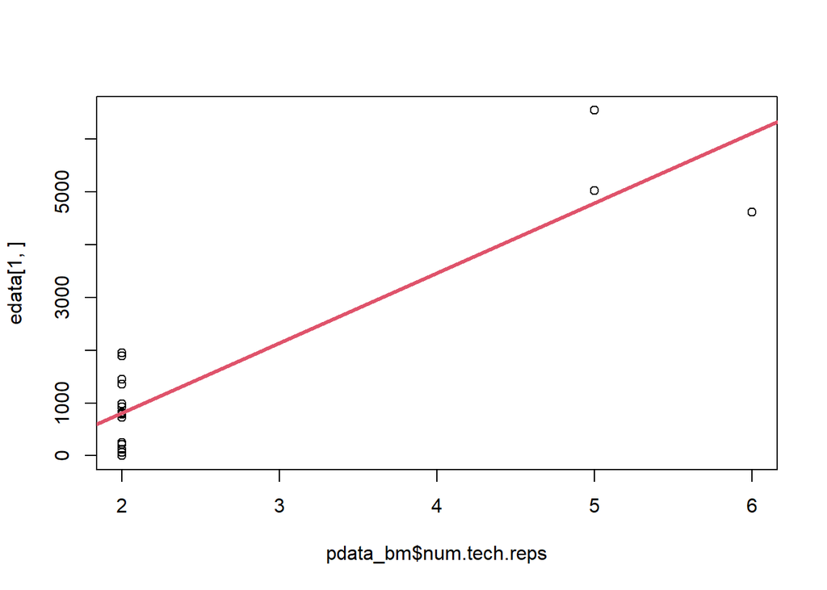

```r
plot(pdata_bm$num.tech.reps,edata[1,])
abline(lm1, col=2, lwd=3)
```

- The difference between 2 and 5 technical replicates is not the same as the difference between 5 and 6 technical replicates.
- **There are very few samples with more than 2 replicates so the estimates for** **those values will not be very good.**
- The variable num.tech.reps is not a good measure of the technical variability in the data.
- There may be different numbers of counts for different numbers of technical replicates.

## Question 4

### 4. A. Load the Bodymap data with the following command

```r
con =url("http://bowtie-bio.sourceforge.net/recount/ExpressionSets/bodymap_eset.RData")
load(file=con)
close(con)
ls()
```

```
##  [1] "bm"                "bodymap.eset"      "centered_data_pca"
##  [4] "con"               "edata"             "edata_centered"
##  [7] "edata_kmeans"      "edata_log2"        "fdata"
## [10] "lm1"               "log2_pca"          "montpick.eset"
## [13] "mp"                "ori_pca"           "pdata"
## [16] "pdata_bm"          "svd1"              "svd2"
## [19] "svd3"
```

```r
bm = bodymap.eset
head(bm)
```

```
## ExpressionSet (storageMode: lockedEnvironment)
## assayData: 6 features, 19 samples
##   element names: exprs
## protocolData: none
## phenoData
##   sampleNames: ERS025098 ERS025092 ... ERS025091 (19 total)
##   varLabels: sample.id num.tech.reps ... race (6 total)
##   varMetadata: labelDescription
## featureData
##   featureNames: ENSG00000000003 ENSG00000000005 ... ENSG00000000938 (6
##     total)
##   fvarLabels: gene
##   fvarMetadata: labelDescription
## experimentData: use 'experimentData(object)'
## Annotation:
```

```r
edata = exprs(bm)
head(edata)
```

```
##                 ERS025098 ERS025092 ERS025085 ERS025088 ERS025089 ERS025082
## ENSG00000000003      1354       216       215       924       725       125
## ENSG00000000005       712       134         4      1495       119        20
## ENSG00000000419       450       547       516       529       808       680
## ENSG00000000457       188       368       196       386       156       259
## ENSG00000000460        66        29         1        26        11         9
## ENSG00000000938       104        79         7        29         0         3
##                 ERS025081 ERS025096 ERS025099 ERS025086 ERS025084 ERS025087
## ENSG00000000003       796      1954       815       249      4614      6548
## ENSG00000000005         7         0         0        16       975       923
## ENSG00000000419       744       369       636       486      1200      2823
## ENSG00000000457       436       288       187       553      1543      1194
## ENSG00000000460        25        42        12        22       213        80
## ENSG00000000938         1        20       243        41       166       265
##                 ERS025093 ERS025083 ERS025095 ERS025097 ERS025094 ERS025090
## ENSG00000000003      5030      1450       781        69      1888       983
## ENSG00000000005       696        15        24         0        20         4
## ENSG00000000419      2159       933       870       621      1026      1185
## ENSG00000000457       876       655       862       242       569       609
## ENSG00000000460        57        13        78        17       351        46
## ENSG00000000938       211        10        11         0         0        22
##                 ERS025091
## ENSG00000000003         3
## ENSG00000000005         0
## ENSG00000000419       765
## ENSG00000000457       782
## ENSG00000000460        73
## ENSG00000000938      1508
```

```r
pdata_bm=pData(bm)
head(pdata_bm)
```

```
##           sample.id num.tech.reps tissue.type gender age      race
## ERS025098 ERS025098             2     adipose      F  73 caucasian
## ERS025092 ERS025092             2     adrenal      M  60 caucasian
## ERS025085 ERS025085             2       brain      F  77 caucasian
## ERS025088 ERS025088             2      breast      F  29 caucasian
## ERS025089 ERS025089             2       colon      F  68 caucasian
## ERS025082 ERS025082             2       heart      M  77 caucasian
```

Fit a linear model relating he first gene’s counts to the age of the person and the sex of the samples. What is the value and interpretation of the coefficient for age?

## 4. B. Fit linear model

```r
lm2 = lm(edata[1,] ~ pdata_bm$age + pdata_bm$gender)
summary(lm2)
```

```
##
## Call:
## lm(formula = edata[1, ] ~ pdata_bm$age + pdata_bm$gender)
##
## Residuals:
##     Min      1Q  Median      3Q     Max
## -734.35 -229.31   -3.26  243.02  768.09
##
## Coefficients:
##                  Estimate Std. Error t value Pr(>|t|)
## (Intercept)      2331.581    438.181   5.321 0.000139 ***
## pdata_bm$age      -23.913      6.488  -3.686 0.002744 **
## pdata_bm$genderM -207.257    236.431  -0.877 0.396610
## ---
## Signif. codes:  0 '***' 0.001 '**' 0.01 '*' 0.05 '.' 0.1 ' ' 1
##
## Residual standard error: 469.6 on 13 degrees of freedom
##   (3 observations deleted due to missingness)
## Multiple R-squared:  0.5147, Adjusted R-squared:   0.44
## F-statistic: 6.894 on 2 and 13 DF,  p-value: 0.009102
```

- -23.25. This coefficient means that there is an average decrease of 23.91 in the count variable per year within each gender.
- 2187.91. This means that for a person that is zero years old, the average count is 2187.91
- **-23.91. This coefficient means that there is an average decrease of 23.91 in the count variable per year within each gender.**
- -207.26. This coefficient means that for each additional year of age, the count goes down by an average of 207.26 for a fixed sex.

## Question 5

### 5. A. Load the Montgomery and Pickrell eSet:

```r
con =url("http://bowtie-bio.sourceforge.net/recount/ExpressionSets/montpick_eset.RData")
load(file=con)
close(con)
ls()
```

```
##  [1] "bm"                "bodymap.eset"      "centered_data_pca"
##  [4] "con"               "edata"             "edata_centered"
##  [7] "edata_kmeans"      "edata_log2"        "fdata"
## [10] "lm1"               "lm2"               "log2_pca"
## [13] "montpick.eset"     "mp"                "ori_pca"
## [16] "pdata"             "pdata_bm"          "svd1"
## [19] "svd2"              "svd3"
```

```r
mp = montpick.eset
head(mp)
```

```
## ExpressionSet (storageMode: lockedEnvironment)
## assayData: 6 features, 129 samples
##   element names: exprs
## protocolData: none
## phenoData
##   sampleNames: NA06985 NA06986 ... NA19257 (129 total)
##   varLabels: sample.id num.tech.reps population study
##   varMetadata: labelDescription
## featureData
##   featureNames: ENSG00000000003 ENSG00000000005 ... ENSG00000000938 (6
##     total)
##   fvarLabels: gene
##   fvarMetadata: labelDescription
## experimentData: use 'experimentData(object)'
## Annotation:
```

```r
pdata=pData(mp)
head(pdata)
```

```
##         sample.id num.tech.reps population      study
## NA06985   NA06985             1        CEU Montgomery
## NA06986   NA06986             1        CEU Montgomery
## NA06994   NA06994             1        CEU Montgomery
## NA07000   NA07000             1        CEU Montgomery
## NA07037   NA07037             1        CEU Montgomery
## NA07051   NA07051             1        CEU Montgomery
```

```r
edata=as.data.frame(exprs(mp))
head(edata)
```

```
##                 NA06985 NA06986 NA06994 NA07000 NA07037 NA07051 NA07346 NA07347
## ENSG00000000003       0       0       0       1       0       0       0       0
## ENSG00000000005       0       0       0       0       0       0       0       0
## ENSG00000000419      11      16      10      19       8      24      14      19
## ENSG00000000457      28      22      17      21      18      15      21      13
## ENSG00000000460       0       7       2       4       6       3       8       5
## ENSG00000000938       8      28      20      10      17       4      19      35
##                 NA07357 NA10847 NA10851 NA11829 NA11830 NA11831 NA11832 NA11840
## ENSG00000000003       0       0       0       0       0       0       0       0
## ENSG00000000005       0       0       0       0       0       0       0       0
## ENSG00000000419      20       6      16       9       8      19      38      40
## ENSG00000000457      18      15      22      20      18      38      46      49
## ENSG00000000460       2       2       4       2       4       7      17      10
## ENSG00000000938      16       9      22       9      21      42      24      36
##                 NA11881 NA11894 NA11918 NA11920 NA11931 NA11992 NA11993 NA11994
## ENSG00000000003       0       0       0       0       1       0       0       0
## ENSG00000000005       0       0       0       0       0       0       0       0
## ENSG00000000419      16      24      16      60      80      43      14      38
## ENSG00000000457      14      14      10      21      46      55      10      37
## ENSG00000000460       1       7       6      18      20       7       0      10
## ENSG00000000938      19      22       0       8      15      27       6      23
##                 NA11995 NA12003 NA12004 NA12005 NA12006 NA12043 NA12044 NA12045
## ENSG00000000003       0       0       0       0       0       0       0       1
## ENSG00000000005       0       0       0       0       0       0       0       0
## ENSG00000000419      21      25       0      16      51      42      65      61
## ENSG00000000457      42      16      19      30      19      72      95      69
## ENSG00000000460       6       9       0       0       0      15      15      14
## ENSG00000000938       5      22       0      49      60      25      15      57
##                 NA12144 NA12154 NA12155 NA12156 NA12234 NA12249 NA12287 NA12414
## ENSG00000000003       0       0       0       0       0       0       0       1
## ENSG00000000005       0       0       0       0       0       0       0       1
## ENSG00000000419      35      37      42      20      33      36      29      47
## ENSG00000000457      20      59      41      27      38      42      28      55
## ENSG00000000460       9       9       5       5      12       5      11       5
## ENSG00000000938      27      25       6      11      27      13       5      34
##                 NA12489 NA12716 NA12717 NA12750 NA12751 NA12760 NA12761 NA12762
## ENSG00000000003       0       0       0       0       0       0       0       0
## ENSG00000000005       0       0       0       0       0       0       0       0
## ENSG00000000419      30      16      16      25      25      24      21      19
## ENSG00000000457      41      44      14      24      33      51      10       9
```

[output cut: 64 more lines]

```
## ENSG00000000938      73      12     100      71      55      28      35      50
##                 NA19203 NA19204 NA19209 NA19210 NA19222 NA19225 NA19238 NA19239
## ENSG00000000003       0       0       0       0       0       0       0       0
## ENSG00000000005       0       0       0       0       0       0       0       0
## ENSG00000000419      82      57      63      89      60      76      69      84
## ENSG00000000457      58      86     113      48      71      81      73      87
## ENSG00000000460      10      19      17      12      12       7      21      35
## ENSG00000000938      14      59      27      32      25      19      59      58
##                 NA19257
## ENSG00000000003       0
## ENSG00000000005       0
## ENSG00000000419      76
## ENSG00000000457      81
## ENSG00000000460      11
## ENSG00000000938      34
```

```r
fdata = fData(mp)
head(fdata)
```

```
##                            gene
## ENSG00000000003 ENSG00000000003
## ENSG00000000005 ENSG00000000005
## ENSG00000000419 ENSG00000000419
## ENSG00000000457 ENSG00000000457
## ENSG00000000460 ENSG00000000460
## ENSG00000000938 ENSG00000000938
```

Perform the log2(data + 1) transform. Then fit a regression model to each sample using population as the outcome. Do this using the lm.fit function (hint: don’t forget the intercept). What is the dimension of the residual matrix, the effects matrix and the coefficients matrix?

### 5. B. Log2 transform the expression data

```r
edata = log2(edata + 1)
```

### 5. C. fit a regression model to each sample, using population as the outcome

```r
mod = model.matrix(~ pdata$population)
head(mod)
```

```
##   (Intercept) pdata$populationYRI
## 1           1                   0
## 2           1                   0
## 3           1                   0
## 4           1                   0
## 5           1                   0
## 6           1                   0
```

```r
fit = lm.fit(mod, t(edata))
```

### 5. D. dimension of the residual matrix

```r
dim(fit$residuals)
```

```
## [1]   129 52580
```

### 5. E. Dimension of the effects matrix

```r
dim(fit$effects)
```

```
## [1]   129 52580
```

### 5. F. Dimension of the coefficients matrix

```r
dim(fit$coefficients)
```

```
## [1]     2 52580
```

- Residual matrix: 52580 x 129  
  Effects matrix: 52580 x129  
  Coefficients matrix: 2 x 52580
- Residual matrix: 52580 x 129  
  Effects matrix: 129 x 52580 Coefficients matrix: 2 x 52580
- Residual matrix: 129 x 52580 Effects matrix: 129 x 52580 Coefficients matrix: 1 x 52580
- **Residual matrix: 129 x 52580** **Effects matrix: 129 x 52580** **Coefficients matrix: 2 x 52580**

## Question 6

### 6. A. Load the Montgomery and Pickrell eSet:

```r
con =url("http://bowtie-bio.sourceforge.net/recount/ExpressionSets/montpick_eset.RData")
load(file=con)
close(con)
ls()
```

```
##  [1] "bm"                "bodymap.eset"      "centered_data_pca"
##  [4] "con"               "edata"             "edata_centered"
##  [7] "edata_kmeans"      "edata_log2"        "fdata"
## [10] "fit"               "lm1"               "lm2"
## [13] "log2_pca"          "mod"               "montpick.eset"
## [16] "mp"                "ori_pca"           "pdata"
## [19] "pdata_bm"          "svd1"              "svd2"
## [22] "svd3"
```

```r
mp = montpick.eset
head(mp)
```

```
## ExpressionSet (storageMode: lockedEnvironment)
## assayData: 6 features, 129 samples
##   element names: exprs
## protocolData: none
## phenoData
##   sampleNames: NA06985 NA06986 ... NA19257 (129 total)
##   varLabels: sample.id num.tech.reps population study
##   varMetadata: labelDescription
## featureData
##   featureNames: ENSG00000000003 ENSG00000000005 ... ENSG00000000938 (6
##     total)
##   fvarLabels: gene
##   fvarMetadata: labelDescription
## experimentData: use 'experimentData(object)'
## Annotation:
```

```r
pdata=pData(mp)
head(pdata)
```

```
##         sample.id num.tech.reps population      study
## NA06985   NA06985             1        CEU Montgomery
## NA06986   NA06986             1        CEU Montgomery
## NA06994   NA06994             1        CEU Montgomery
## NA07000   NA07000             1        CEU Montgomery
## NA07037   NA07037             1        CEU Montgomery
## NA07051   NA07051             1        CEU Montgomery
```

```r
edata=as.data.frame(exprs(mp))
head(edata)
```

```
##                 NA06985 NA06986 NA06994 NA07000 NA07037 NA07051 NA07346 NA07347
## ENSG00000000003       0       0       0       1       0       0       0       0
## ENSG00000000005       0       0       0       0       0       0       0       0
## ENSG00000000419      11      16      10      19       8      24      14      19
## ENSG00000000457      28      22      17      21      18      15      21      13
## ENSG00000000460       0       7       2       4       6       3       8       5
## ENSG00000000938       8      28      20      10      17       4      19      35
##                 NA07357 NA10847 NA10851 NA11829 NA11830 NA11831 NA11832 NA11840
## ENSG00000000003       0       0       0       0       0       0       0       0
## ENSG00000000005       0       0       0       0       0       0       0       0
## ENSG00000000419      20       6      16       9       8      19      38      40
## ENSG00000000457      18      15      22      20      18      38      46      49
## ENSG00000000460       2       2       4       2       4       7      17      10
## ENSG00000000938      16       9      22       9      21      42      24      36
##                 NA11881 NA11894 NA11918 NA11920 NA11931 NA11992 NA11993 NA11994
## ENSG00000000003       0       0       0       0       1       0       0       0
## ENSG00000000005       0       0       0       0       0       0       0       0
## ENSG00000000419      16      24      16      60      80      43      14      38
## ENSG00000000457      14      14      10      21      46      55      10      37
## ENSG00000000460       1       7       6      18      20       7       0      10
## ENSG00000000938      19      22       0       8      15      27       6      23
##                 NA11995 NA12003 NA12004 NA12005 NA12006 NA12043 NA12044 NA12045
## ENSG00000000003       0       0       0       0       0       0       0       1
## ENSG00000000005       0       0       0       0       0       0       0       0
## ENSG00000000419      21      25       0      16      51      42      65      61
## ENSG00000000457      42      16      19      30      19      72      95      69
## ENSG00000000460       6       9       0       0       0      15      15      14
## ENSG00000000938       5      22       0      49      60      25      15      57
##                 NA12144 NA12154 NA12155 NA12156 NA12234 NA12249 NA12287 NA12414
## ENSG00000000003       0       0       0       0       0       0       0       1
## ENSG00000000005       0       0       0       0       0       0       0       1
## ENSG00000000419      35      37      42      20      33      36      29      47
## ENSG00000000457      20      59      41      27      38      42      28      55
## ENSG00000000460       9       9       5       5      12       5      11       5
## ENSG00000000938      27      25       6      11      27      13       5      34
##                 NA12489 NA12716 NA12717 NA12750 NA12751 NA12760 NA12761 NA12762
## ENSG00000000003       0       0       0       0       0       0       0       0
## ENSG00000000005       0       0       0       0       0       0       0       0
## ENSG00000000419      30      16      16      25      25      24      21      19
## ENSG00000000457      41      44      14      24      33      51      10       9
```

[output cut: 64 more lines]

```
## ENSG00000000938      73      12     100      71      55      28      35      50
##                 NA19203 NA19204 NA19209 NA19210 NA19222 NA19225 NA19238 NA19239
## ENSG00000000003       0       0       0       0       0       0       0       0
## ENSG00000000005       0       0       0       0       0       0       0       0
## ENSG00000000419      82      57      63      89      60      76      69      84
## ENSG00000000457      58      86     113      48      71      81      73      87
## ENSG00000000460      10      19      17      12      12       7      21      35
## ENSG00000000938      14      59      27      32      25      19      59      58
##                 NA19257
## ENSG00000000003       0
## ENSG00000000005       0
## ENSG00000000419      76
## ENSG00000000457      81
## ENSG00000000460      11
## ENSG00000000938      34
```

```r
fdata = fData(mp)
head(fdata)
```

```
##                            gene
## ENSG00000000003 ENSG00000000003
## ENSG00000000005 ENSG00000000005
## ENSG00000000419 ENSG00000000419
## ENSG00000000457 ENSG00000000457
## ENSG00000000460 ENSG00000000460
## ENSG00000000938 ENSG00000000938
```

Perform the log2(data + 1) transform. Then fit a regression model to each sample using population as the outcome. Do this using the lm.fit function (hint: don’t forget the intercept). What is the effects matrix?

### 6. B. Log2 transform the expression data

```r
edata = log2(edata + 1)
```

### 6. C. Fit a regression model to each sample, using population as the outcome

```r
mod = model.matrix(~ pdata$population)
fit = lm.fit(mod, t(edata))
```

- **The estimated fitted values for all samples for each gene, with the values for each gene stored in the columns of the matrix.**
- The model coefficients for all samples for each gene, with the values for each gene stored in the rows of the matrix.
- The model coefficients for all samples for each gene, with the values for each gene stored in the columns of the matrix.
- The estimated fitted values for all samples for each gene, with the values for each gene stored in the rows of the matrix.

## Question 7

### 7. A. Load the Bodymap data with the following command

```r
con =url("http://bowtie-bio.sourceforge.net/recount/ExpressionSets/bodymap_eset.RData")
load(file=con)
close(con)
ls()
```

```
##  [1] "bm"                "bodymap.eset"      "centered_data_pca"
##  [4] "con"               "edata"             "edata_centered"
##  [7] "edata_kmeans"      "edata_log2"        "fdata"
## [10] "fit"               "lm1"               "lm2"
## [13] "log2_pca"          "mod"               "montpick.eset"
## [16] "mp"                "ori_pca"           "pdata"
## [19] "pdata_bm"          "svd1"              "svd2"
## [22] "svd3"
```

```r
bm = bodymap.eset
head(bm)
```

```
## ExpressionSet (storageMode: lockedEnvironment)
## assayData: 6 features, 19 samples
##   element names: exprs
## protocolData: none
## phenoData
##   sampleNames: ERS025098 ERS025092 ... ERS025091 (19 total)
##   varLabels: sample.id num.tech.reps ... race (6 total)
##   varMetadata: labelDescription
## featureData
##   featureNames: ENSG00000000003 ENSG00000000005 ... ENSG00000000938 (6
##     total)
##   fvarLabels: gene
##   fvarMetadata: labelDescription
## experimentData: use 'experimentData(object)'
## Annotation:
```

```r
edata = exprs(bm)
head(edata)
```

```
##                 ERS025098 ERS025092 ERS025085 ERS025088 ERS025089 ERS025082
## ENSG00000000003      1354       216       215       924       725       125
## ENSG00000000005       712       134         4      1495       119        20
## ENSG00000000419       450       547       516       529       808       680
## ENSG00000000457       188       368       196       386       156       259
## ENSG00000000460        66        29         1        26        11         9
## ENSG00000000938       104        79         7        29         0         3
##                 ERS025081 ERS025096 ERS025099 ERS025086 ERS025084 ERS025087
## ENSG00000000003       796      1954       815       249      4614      6548
## ENSG00000000005         7         0         0        16       975       923
## ENSG00000000419       744       369       636       486      1200      2823
## ENSG00000000457       436       288       187       553      1543      1194
## ENSG00000000460        25        42        12        22       213        80
## ENSG00000000938         1        20       243        41       166       265
##                 ERS025093 ERS025083 ERS025095 ERS025097 ERS025094 ERS025090
## ENSG00000000003      5030      1450       781        69      1888       983
## ENSG00000000005       696        15        24         0        20         4
## ENSG00000000419      2159       933       870       621      1026      1185
## ENSG00000000457       876       655       862       242       569       609
## ENSG00000000460        57        13        78        17       351        46
## ENSG00000000938       211        10        11         0         0        22
##                 ERS025091
## ENSG00000000003         3
## ENSG00000000005         0
## ENSG00000000419       765
## ENSG00000000457       782
## ENSG00000000460        73
## ENSG00000000938      1508
```

```r
pdata_bm=pData(bm)
head(pdata_bm)
```

```
##           sample.id num.tech.reps tissue.type gender age      race
## ERS025098 ERS025098             2     adipose      F  73 caucasian
## ERS025092 ERS025092             2     adrenal      M  60 caucasian
## ERS025085 ERS025085             2       brain      F  77 caucasian
## ERS025088 ERS025088             2      breast      F  29 caucasian
## ERS025089 ERS025089             2       colon      F  68 caucasian
## ERS025082 ERS025082             2       heart      M  77 caucasian
```

Fit many regression models to the expression data where age is the outcome variable using the lmFit function from the limma package (hint: you may have to subset the expression data to the samples without missing values of age to get the model to fit). What is the coefficient for age for the 1,000th gene? Make a plot of the data and fitted values for this gene. Does the model fit well?

### 7. B. Load Libraries

```r
library(devtools)
library(Biobase)
library(limma)
library(edge)
```

### 7. C. Subset the expression data to the samples without missing values of age

```r
pdata_bm = na.omit(pdata_bm)
edata = edata[,rownames(pdata_bm), drop=FALSE]
head(edata)
```

```
##                 ERS025098 ERS025092 ERS025085 ERS025088 ERS025089 ERS025082
## ENSG00000000003      1354       216       215       924       725       125
## ENSG00000000005       712       134         4      1495       119        20
## ENSG00000000419       450       547       516       529       808       680
## ENSG00000000457       188       368       196       386       156       259
## ENSG00000000460        66        29         1        26        11         9
## ENSG00000000938       104        79         7        29         0         3
##                 ERS025081 ERS025096 ERS025099 ERS025086 ERS025083 ERS025095
## ENSG00000000003       796      1954       815       249      1450       781
## ENSG00000000005         7         0         0        16        15        24
## ENSG00000000419       744       369       636       486       933       870
## ENSG00000000457       436       288       187       553       655       862
## ENSG00000000460        25        42        12        22        13        78
## ENSG00000000938         1        20       243        41        10        11
##                 ERS025097 ERS025094 ERS025090 ERS025091
## ENSG00000000003        69      1888       983         3
## ENSG00000000005         0        20         4         0
## ENSG00000000419       621      1026      1185       765
## ENSG00000000457       242       569       609       782
## ENSG00000000460        17       351        46        73
## ENSG00000000938         0         0        22      1508
```

### 7. D. Fit many regression models to the expression data where age is the outcome

```r
mod_adj = model.matrix(~ pdata_bm$age)
mod_adj
```

```
##    (Intercept) pdata_bm$age
## 1            1           73
## 2            1           60
## 3            1           77
## 4            1           29
## 5            1           68
## 6            1           77
## 7            1           60
## 8            1           37
## 9            1           65
## 10           1           86
## 11           1           47
## 12           1           73
## 13           1           77
## 14           1           19
## 15           1           60
## 16           1           58
## attr(,"assign")
## [1] 0 1
```

```r
fit_limma = lmFit(edata,mod_adj)
dim(fit_limma$coefficients)
```

```
## [1] 52580     2
```

```r
fit_limma$coefficients[1000,]
```

```
##  (Intercept) pdata_bm$age
##   2469.87375    -27.61178
```

### 7. E. make a plot of the 1,000th gene and fitted values

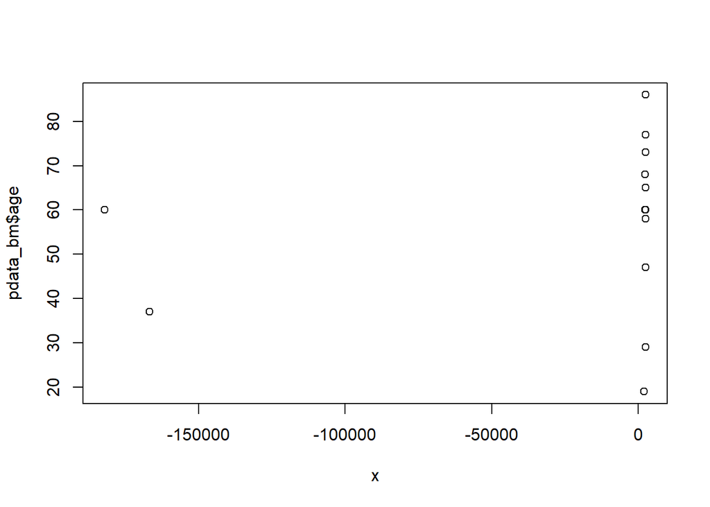

```r
intercept = fit_limma$coefficients[1000,][1]
slope = fit_limma$coefficients[1000,][2]
x = edata[1000,]*slope+intercept
plot(x,pdata_bm$age)
```

- -27.61. The model fits well since there seems to be a flat trend in the counts.
- -27.61. The model doesn’t fit well since there appears to be a non-linear trend in the data.
- 2469.87. The model doesn’t fit well since there appears to be a non-linear trend in the data.
- **-27.61. The model doesn’t fit well since there are two large outlying values and the rest of the values are near zero.**

## Question 8

### 8. A. Load the Bodymap data with the following command

```r
con =url("http://bowtie-bio.sourceforge.net/recount/ExpressionSets/bodymap_eset.RData")
load(file=con)
close(con)
ls()
```

```
##  [1] "bm"                "bodymap.eset"      "centered_data_pca"
##  [4] "con"               "edata"             "edata_centered"
##  [7] "edata_kmeans"      "edata_log2"        "fdata"
## [10] "fit"               "fit_limma"         "intercept"
## [13] "lm1"               "lm2"               "log2_pca"
## [16] "mod"               "mod_adj"           "montpick.eset"
## [19] "mp"                "ori_pca"           "pdata"
## [22] "pdata_bm"          "slope"             "svd1"
## [25] "svd2"              "svd3"              "x"
```

```r
bm = bodymap.eset
head(bm)
```

```
## ExpressionSet (storageMode: lockedEnvironment)
## assayData: 6 features, 19 samples
##   element names: exprs
## protocolData: none
## phenoData
##   sampleNames: ERS025098 ERS025092 ... ERS025091 (19 total)
##   varLabels: sample.id num.tech.reps ... race (6 total)
##   varMetadata: labelDescription
## featureData
##   featureNames: ENSG00000000003 ENSG00000000005 ... ENSG00000000938 (6
##     total)
##   fvarLabels: gene
##   fvarMetadata: labelDescription
## experimentData: use 'experimentData(object)'
## Annotation:
```

```r
edata = exprs(bm)
head(edata)
```

```
##                 ERS025098 ERS025092 ERS025085 ERS025088 ERS025089 ERS025082
## ENSG00000000003      1354       216       215       924       725       125
## ENSG00000000005       712       134         4      1495       119        20
## ENSG00000000419       450       547       516       529       808       680
## ENSG00000000457       188       368       196       386       156       259
## ENSG00000000460        66        29         1        26        11         9
## ENSG00000000938       104        79         7        29         0         3
##                 ERS025081 ERS025096 ERS025099 ERS025086 ERS025084 ERS025087
## ENSG00000000003       796      1954       815       249      4614      6548
## ENSG00000000005         7         0         0        16       975       923
## ENSG00000000419       744       369       636       486      1200      2823
## ENSG00000000457       436       288       187       553      1543      1194
## ENSG00000000460        25        42        12        22       213        80
## ENSG00000000938         1        20       243        41       166       265
##                 ERS025093 ERS025083 ERS025095 ERS025097 ERS025094 ERS025090
## ENSG00000000003      5030      1450       781        69      1888       983
## ENSG00000000005       696        15        24         0        20         4
## ENSG00000000419      2159       933       870       621      1026      1185
## ENSG00000000457       876       655       862       242       569       609
## ENSG00000000460        57        13        78        17       351        46
## ENSG00000000938       211        10        11         0         0        22
##                 ERS025091
## ENSG00000000003         3
## ENSG00000000005         0
## ENSG00000000419       765
## ENSG00000000457       782
## ENSG00000000460        73
## ENSG00000000938      1508
```

```r
pdata_bm=pData(bm)
head(pdata_bm)
```

```
##           sample.id num.tech.reps tissue.type gender age      race
## ERS025098 ERS025098             2     adipose      F  73 caucasian
## ERS025092 ERS025092             2     adrenal      M  60 caucasian
## ERS025085 ERS025085             2       brain      F  77 caucasian
## ERS025088 ERS025088             2      breast      F  29 caucasian
## ERS025089 ERS025089             2       colon      F  68 caucasian
## ERS025082 ERS025082             2       heart      M  77 caucasian
```

Fit many regression models to the expression data where age is the outcome variable and tissue.type is an adjustment variable using the lmFit function from the limma package (hint: you may have to subset the expression data to the samples without missing values of age to get the model to fit). What is wrong with this model?

### 8. B. Subset the expression data to the samples without missing values of age

```r
pdata_bm = na.omit(pdata_bm)
edata = edata[,rownames(pdata_bm), drop=FALSE]
```

### 8. C. Fit many regression models to the expression data where age is the outcome

### and tissue type is the adjustment variable

```r
mod_adj = model.matrix(~ pdata_bm$age + as.factor(pdata_bm$tissue.type))
mod_adj
```

```
##    (Intercept) pdata_bm$age as.factor(pdata_bm$tissue.type)adrenal
## 1            1           73                                      0
## 2            1           60                                      1
## 3            1           77                                      0
## 4            1           29                                      0
## 5            1           68                                      0
## 6            1           77                                      0
## 7            1           60                                      0
## 8            1           37                                      0
## 9            1           65                                      0
## 10           1           86                                      0
## 11           1           47                                      0
## 12           1           73                                      0
## 13           1           77                                      0
## 14           1           19                                      0
```

[output cut: 160 more lines]

```r
fit_limma = lmFit(edata,mod_adj)
```

```
## Coefficients not estimable: as.factor(pdata_bm$tissue.type)white_blood_cell as.factor(pdata_bm$tissue.type)mixture
```

```r
pdata_bm$tissue.type
```

```
##  [1] adipose          adrenal          brain            breast
##  [5] colon            heart            kidney           liver
##  [9] lung             lymphnode        ovary            prostate
## [13] skeletal_muscle  testes           thyroid          white_blood_cell
## 17 Levels: adipose adrenal brain breast colon heart kidney liver ... white_blood_cell
```

### 8. E. There are only 16 data points per gene in the expression data (edata)

```r
dim(edata)
```

```
## [1] 52580    16
```

- This model doesn’t fit well since tissue.type makes more sense as an outcome variable.
- **Since tissue.type is a factor variable with many levels, this model has more** **coefficients to estimate per gene (18) than data points per gene (16).**
- The model doesn’t fit well since age should be treated as a factor variable.
- The model doesn’t fit well because there are a large number of outliers for the white blood cell tissue.

## Question 9

### 9. A. Multicollinearity between the population and study variables

```r
head(pdata)
```

```
##         sample.id num.tech.reps population      study
## NA06985   NA06985             1        CEU Montgomery
## NA06986   NA06986             1        CEU Montgomery
## NA06994   NA06994             1        CEU Montgomery
## NA07000   NA07000             1        CEU Montgomery
## NA07037   NA07037             1        CEU Montgomery
## NA07051   NA07051             1        CEU Montgomery
```

```r
pop = as.numeric(as.factor(pdata$population))
pop
```

```
##   [1] 1 1 1 1 1 1 1 1 1 1 1 1 1 1 1 1 1 1 1 1 1 1 1 1 1 1 1 1 1 1 1 1 1 1 1 1 1
##  [38] 1 1 1 1 1 1 1 1 1 1 1 1 1 1 1 1 1 1 1 1 1 1 1 2 2 2 2 2 2 2 2 2 2 2 2 2 2
##  [75] 2 2 2 2 2 2 2 2 2 2 2 2 2 2 2 2 2 2 2 2 2 2 2 2 2 2 2 2 2 2 2 2 2 2 2 2 2
## [112] 2 2 2 2 2 2 2 2 2 2 2 2 2 2 2 2 2 2
```

```r
study = as.numeric(as.factor(pdata$study))
study
```

```
##   [1] 1 1 1 1 1 1 1 1 1 1 1 1 1 1 1 1 1 1 1 1 1 1 1 1 1 1 1 1 1 1 1 1 1 1 1 1 1
##  [38] 1 1 1 1 1 1 1 1 1 1 1 1 1 1 1 1 1 1 1 1 1 1 1 2 2 2 2 2 2 2 2 2 2 2 2 2 2
##  [75] 2 2 2 2 2 2 2 2 2 2 2 2 2 2 2 2 2 2 2 2 2 2 2 2 2 2 2 2 2 2 2 2 2 2 2 2 2
## [112] 2 2 2 2 2 2 2 2 2 2 2 2 2 2 2 2 2 2
```

```r
cor.test(pop, study)
```

```
##
##  Pearson's product-moment correlation
##
## data:  pop and study
## t = 534769648, df = 127, p-value < 2.2e-16
## alternative hypothesis: true correlation is not equal to 0
## 95 percent confidence interval:
##  1 1
## sample estimates:
## cor
##   1
```

Why is it difficult to distinguish the study effect from the population effect in the Montgomery Pickrell dataset from ReCount?

- **The effects are difficult to distinguish because the study variable and** **population variable are perfectly correlated.**
- The study effects and population effects are difficult to distinguish because of confounding, we can estimate the population effects by adjusting for study.
- The study effects and population effects are difficult to distinguish because the study effects are stronger.
- The study effects and population effects are difficult to distinguish because the study effects appear in the first principal component.

## Question 10

### 10. A. Load the Bodymap data with the following command

```r
con =url("http://bowtie-bio.sourceforge.net/recount/ExpressionSets/bodymap_eset.RData")
load(file=con)
close(con)
ls()
```

```
##  [1] "bm"                "bodymap.eset"      "centered_data_pca"
##  [4] "con"               "edata"             "edata_centered"
##  [7] "edata_kmeans"      "edata_log2"        "fdata"
## [10] "fit"               "fit_limma"         "intercept"
## [13] "lm1"               "lm2"               "log2_pca"
## [16] "mod"               "mod_adj"           "montpick.eset"
## [19] "mp"                "ori_pca"           "pdata"
## [22] "pdata_bm"          "pop"               "slope"
## [25] "study"             "svd1"              "svd2"
## [28] "svd3"              "x"
```

```r
bm = bodymap.eset
head(bm)
```

```
## ExpressionSet (storageMode: lockedEnvironment)
## assayData: 6 features, 19 samples
##   element names: exprs
## protocolData: none
## phenoData
##   sampleNames: ERS025098 ERS025092 ... ERS025091 (19 total)
##   varLabels: sample.id num.tech.reps ... race (6 total)
##   varMetadata: labelDescription
## featureData
##   featureNames: ENSG00000000003 ENSG00000000005 ... ENSG00000000938 (6
##     total)
##   fvarLabels: gene
##   fvarMetadata: labelDescription
## experimentData: use 'experimentData(object)'
## Annotation:
```

```r
edata = exprs(bm)
head(edata)
```

```
##                 ERS025098 ERS025092 ERS025085 ERS025088 ERS025089 ERS025082
## ENSG00000000003      1354       216       215       924       725       125
## ENSG00000000005       712       134         4      1495       119        20
## ENSG00000000419       450       547       516       529       808       680
## ENSG00000000457       188       368       196       386       156       259
## ENSG00000000460        66        29         1        26        11         9
## ENSG00000000938       104        79         7        29         0         3
##                 ERS025081 ERS025096 ERS025099 ERS025086 ERS025084 ERS025087
## ENSG00000000003       796      1954       815       249      4614      6548
## ENSG00000000005         7         0         0        16       975       923
## ENSG00000000419       744       369       636       486      1200      2823
## ENSG00000000457       436       288       187       553      1543      1194
## ENSG00000000460        25        42        12        22       213        80
## ENSG00000000938         1        20       243        41       166       265
##                 ERS025093 ERS025083 ERS025095 ERS025097 ERS025094 ERS025090
## ENSG00000000003      5030      1450       781        69      1888       983
## ENSG00000000005       696        15        24         0        20         4
## ENSG00000000419      2159       933       870       621      1026      1185
## ENSG00000000457       876       655       862       242       569       609
## ENSG00000000460        57        13        78        17       351        46
## ENSG00000000938       211        10        11         0         0        22
##                 ERS025091
## ENSG00000000003         3
## ENSG00000000005         0
## ENSG00000000419       765
## ENSG00000000457       782
## ENSG00000000460        73
## ENSG00000000938      1508
```

```r
pdata_bm=pData(bm)
head(pdata)
```

```
##         sample.id num.tech.reps population      study
## NA06985   NA06985             1        CEU Montgomery
## NA06986   NA06986             1        CEU Montgomery
## NA06994   NA06994             1        CEU Montgomery
## NA07000   NA07000             1        CEU Montgomery
## NA07037   NA07037             1        CEU Montgomery
## NA07051   NA07051             1        CEU Montgomery
```

Set the seed using the command set.seed(33353) then estimate a single surrogate variable using the sva function after log2(data + 1) transforming the expression data, removing rows with rowMeans less than 1, and treating age as the outcome (hint: you may have to subset the expression data to the samples without missing values of age to get the model to fit). What is the correlation between the estimated surrogate for batch and age? Is the surrogate more highly correlated with race or gender?

### 10. B. Loading Libraries

```r
library(devtools)
library(Biobase)
library(sva)
library(bladderbatch)
library(snpStats)
```

### 10. C. Preprocessing the data

```r
set.seed(33353)
pheno = na.omit(pdata_bm)
edata = edata[,rownames(pheno), drop=FALSE]
edata = log2(edata + 1)
edata = edata[rowMeans(edata) > 1,]
```

### 10. D. Fit a sva model

```r
mod = model.matrix(~age, data=pheno)
mod
```

```
##           (Intercept) age
## ERS025098           1  73
## ERS025092           1  60
## ERS025085           1  77
## ERS025088           1  29
## ERS025089           1  68
## ERS025082           1  77
## ERS025081           1  60
## ERS025096           1  37
## ERS025099           1  65
## ERS025086           1  86
## ERS025083           1  47
## ERS025095           1  73
## ERS025097           1  77
## ERS025094           1  19
## ERS025090           1  60
## ERS025091           1  58
## attr(,"assign")
## [1] 0 1
```

```r
mod0 = model.matrix(~1, data=pheno)
mod0
```

```
##           (Intercept)
## ERS025098           1
## ERS025092           1
## ERS025085           1
## ERS025088           1
## ERS025089           1
## ERS025082           1
## ERS025081           1
## ERS025096           1
## ERS025099           1
## ERS025086           1
## ERS025083           1
## ERS025095           1
## ERS025097           1
## ERS025094           1
## ERS025090           1
## ERS025091           1
## attr(,"assign")
## [1] 0
```

```r
sva1 = sva(edata, mod,mod0, n.sv=1)
```

```
## Number of significant surrogate variables is:  1
## Iteration (out of 5 ):1  2  3  4  5
```

### 10. E. Correlation between surrogate for batch and age

```r
cor(sva1$sv, pheno$age)
```

```
##            [,1]
## [1,] -0.2029369
```

### 10. F. Correlation between surrogate for batch and race

```r
cor(sva1$sv, as.numeric(pheno$race))
```

```
##            [,1]
## [1,] -0.2296441
```

### 10. G. Correlation between surrogate for batch and gender

```r
cor(sva1$sv, as.numeric(pheno$gender))
```

```
##            [,1]
## [1,] -0.3479958
```

- Correlation with age: 0.99 More highly correlated with race.
- **Correlation with age: 0.20 More highly correlated with gender.**
- Correlation with age: 0.99 More highly correlated with gender.
- Correlation with age: 0.33 More highly correlated with gender.

```r
Sys.Date()
```

```
## [1] "2025-11-26"
```